# DATA607_homework5_Airlinedelay

Yun Mai

March 4, 2017

## Analysis for airline arrival delay

Transform the wide dataset to tidy format. In the new dataset, one variable will form one column, one observation will form one row, and all observational units needed for the analysis will form a table. With the tidy dataset, the arrival delays for the two airlines across five destinations will be analyzed and compared.

# Load the packages required for data tidying and analysis

```r
library(RCurl)
library(tidyr)
library(dplyr)
library(zoo)
```

```r
library(knitr)
library(ggplot2)
```

# Load the original dataset

```r
airdelay_url <- "https://raw.githubusercontent.com/YunMai-SPS/DA607-homework/master/Airline_delay.csv"
airdelay_raw <- read.csv(airdelay_url,header = T, sep=",",quote = "",stringsAsFactors = FALSE, na.strings=c("","NA"))
View(airdelay_raw)
# review the variables and observations in the dataset
str(airdelay_raw)
```

```
## 'data.frame':    6 obs. of  7 variables:
##  $ X            : chr  "ALASKA" NA NA "AM WEST" ...
##  $ X.1          : chr  "on time" "delayed" NA "on time" ...
##  $ Los.Angeles  : int  497 62 NA 694 117 NA
##  $ Phoenix      : int  221 12 NA 4840 415 NA
##  $ San.Diego    : int  212 20 NA 383 65 NA
##  $ San.Francisco: int  503 102 NA 320 129 NA
##  $ Seattle      : int  1841 305 NA 201 61 NA
```

# Clean the data

```r
# view the raw dataset
kable(airdelay_raw)
```

| X | X.1 | Los.Angeles | Phoenix | San.Diego | San.Francisco | Seattle |
| --- | --- | --- | --- | --- | --- | --- |
| ALASKA | on time | 497 | 221 | 212 | 503 | 1841 |
| NA | delayed | 62 | 12 | 20 | 102 | 305 |
| NA | NA | NA | NA | NA | NA | NA |
| AM WEST | on time | 694 | 4840 | 383 | 320 | 201 |
| NA | delayed | 117 | 415 | 65 | 129 | 61 |
| Source: Numbersense \| Kaiser Fung \| McGraw Hill\| 2013 | NA | NA | NA | NA | NA | NA |

```r
# name the first two columns
colnames(airdelay_raw)[c(1,2)] <- c("Airline","Performance")
# replace each NA with the most recent non-NA prior to it
airdelay_raw1 <- transform(airdelay_raw, Airline=na.locf(Airline))
# drop rows containing NA
airdelay_raw2 <- drop_na(airdelay_raw1)
kable(airdelay_raw2)
```

|  | Airline | Performance | Los.Angeles | Phoenix | San.Diego | San.Francisco | Seattle |
| --- | --- | --- | --- | --- | --- | --- | --- |
| 1 | ALASKA | on time | 497 | 221 | 212 | 503 | 1841 |
| 2 | ALASKA | delayed | 62 | 12 | 20 | 102 | 305 |
| 4 | AM WEST | on time | 694 | 4840 | 383 | 320 | 201 |
| 5 | AM WEST | delayed | 117 | 415 | 65 | 129 | 61 |

# Reshape the raw dataset to the long version which is easier to perform the analysis

```r
# collapse 5 columns with Destinations as header into 2 columns; then generate two columns for on-time and delayed flights; add three new derived variales - total, proportion of delayed and on-time
airdelay_raw3 <- airdelay_raw2 %>%
  gather(Destination, Number,3:7) %>%
  spread(Performance, Number)
# change the column name "on time" to a valid fromat,"on_time", for the mutate function
colnames(airdelay_raw3)[4] <- "on_time"
airdelay_tidy1 <- mutate(airdelay_raw3,Total = on_time + delayed, Proportion_delayed = delayed/Total, Proportion_ontime = on_time/Total)
kable(airdelay_tidy1)
```

| Airline | Destination | delayed | on_time | Total | Proportion_delayed | Proportion_ontime |
| --- | --- | --- | --- | --- | --- | --- |
| ALASKA | Los.Angeles | 62 | 497 | 559 | 0.1109123 | 0.8890877 |
| ALASKA | Phoenix | 12 | 221 | 233 | 0.0515021 | 0.9484979 |
| ALASKA | San.Diego | 20 | 212 | 232 | 0.0862069 | 0.9137931 |
| ALASKA | San.Francisco | 102 | 503 | 605 | 0.1685950 | 0.8314050 |
| ALASKA | Seattle | 305 | 1841 | 2146 | 0.1421249 | 0.8578751 |
| AM WEST | Los.Angeles | 117 | 694 | 811 | 0.1442663 | 0.8557337 |
| AM WEST | Phoenix | 415 | 4840 | 5255 | 0.0789724 | 0.9210276 |
| AM WEST | San.Diego | 65 | 383 | 448 | 0.1450893 | 0.8549107 |
| AM WEST | San.Francisco | 129 | 320 | 449 | 0.2873051 | 0.7126949 |
| AM WEST | Seattle | 61 | 201 | 262 | 0.2328244 | 0.7671756 |

# Analysis and Plots

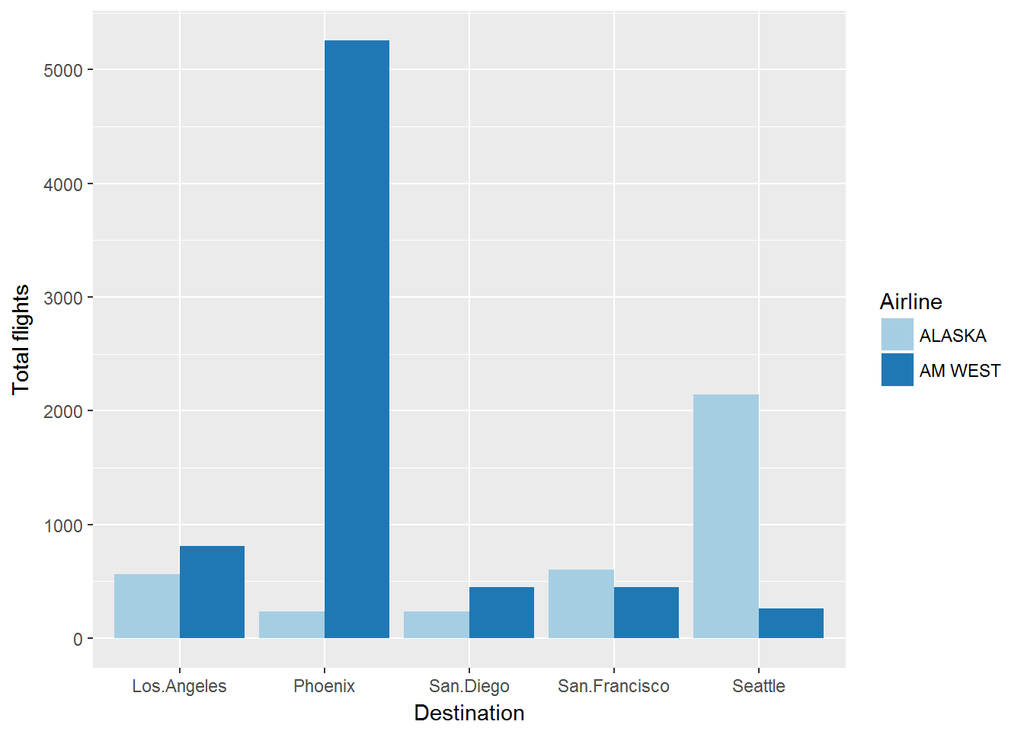

```r
# plot total counts of flights for the two Airlines accross five destinations
ggplot(airdelay_tidy1, aes(x = Destination, y = Total, fill = Airline)) +
  geom_bar(stat="identity", position = "dodge") +
  labs(y = "Total flights") +
  scale_fill_brewer(palette = "Paired")
```

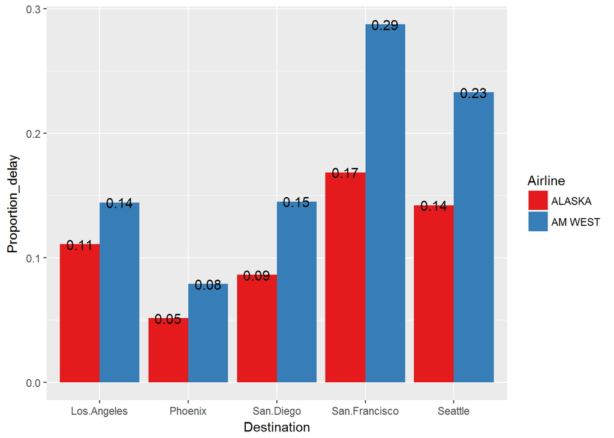

```r
# plot arrival delay rate for the two Airlines accross five destinations
ggplot(airdelay_tidy1, aes(x = Destination, y = Proportion_delayed, fill = Airline)) +
  geom_bar(stat="identity", position = "dodge") +
  scale_fill_brewer(palette = "Set1") +
  labs(y = "Proportion_delay") +
  geom_text(aes(label = round(Proportion_delayed, digits = 2)), color='black', position=position_dodge(.9), size=4)
```

**Figure 2. The arrival delay rates of ALASKA Airline and AM WEST accross the five airports.**

It is easy to conclude from the bar graph:

1. Arrival delay occurs more frequently to AM WEST than to ALASKA Airline across the five airports, especially at San. Francisco and Seattle.
2. To both of the airlines, Phoenix has the lowest arrvial delay rate and San. Froncisco has the highest arrival delay rate accross the five airports.
3. One of the possbile reasons why AM WEST has the lowest rate of arrival delay at Phoenix Airport is that it is familiar with the ariline since it flies a lot more to this airport than to the other four airports. It is worthwhile to notice that ALASKA Airline also has the lowest arrival delay rate at Phoenix Airport even though that airline only accounts for a very small amount of its flights. This indicates that Phoenix Airport may has optimized schedule to decrease the effects of season, whether, weekday etc. on the performance.

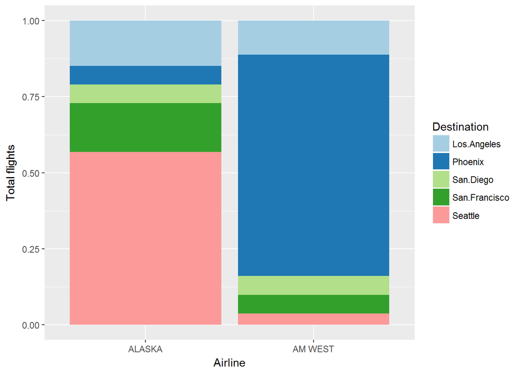

```r
# plot total flights for the two Airlines accross five destinations with stacked bar graph
ggplot(airdelay_tidy1, aes(x = Airline, y = Total, fill = Destination)) +
  geom_bar(stat="identity", position = "fill") +
  labs(y = "Total flights") +
  scale_fill_brewer(palette = "Paired")
```

**Figure 3. The stacked bar graph for the total flights of ALASKA Airline and AM WEST to the five airports.**

```r
# calculate the delay rate and on-time rate in all flights of ALASKA
airdelay_tidy2_1 <- airdelay_tidy1 %>%
  filter(Airline %in% "ALASKA") %>%
  mutate(All_Flight = sum(Total), Delayed_to_all = delayed/All_Flight ,Ontime_to_all = on_time/All_Flight)

# calculate the delay rate and on-time rate in all flights of AM WEST
airdelay_tidy2_2 <-airdelay_tidy1 %>%
  filter(Airline %in% "AM WEST") %>%
  mutate(All_Flight = sum(Total), Delayed_to_all = delayed/All_Flight ,Ontime_to_all = on_time/All_Flight)

# join two mutated datasets
airdelay_tidy2 <- bind_rows(airdelay_tidy2_1, airdelay_tidy2_2)

kable(airdelay_tidy2)
```

| Airline | Destination | delayed | on_time | Total | Proportion_delayed | Proportion_ontime | All_Flight | Delayed_to_all | Ontime_to_all |
| --- | --- | --- | --- | --- | --- | --- | --- | --- | --- |
| ALASKA | Los.Angeles | 62 | 497 | 559 | 0.1109123 | 0.8890877 | 3775 | 0.0164238 | 0.1316556 |
| ALASKA | Phoenix | 12 | 221 | 233 | 0.0515021 | 0.9484979 | 3775 | 0.0031788 | 0.0585430 |
| ALASKA | San.Diego | 20 | 212 | 232 | 0.0862069 | 0.9137931 | 3775 | 0.0052980 | 0.0561589 |
| ALASKA | San.Francisco | 102 | 503 | 605 | 0.1685950 | 0.8314050 | 3775 | 0.0270199 | 0.1332450 |
| ALASKA | Seattle | 305 | 1841 | 2146 | 0.1421249 | 0.8578751 | 3775 | 0.0807947 | 0.4876821 |
| AM WEST | Los.Angeles | 117 | 694 | 811 | 0.1442663 | 0.8557337 | 7225 | 0.0161938 | 0.0960554 |
| AM WEST | Phoenix | 415 | 4840 | 5255 | 0.0789724 | 0.9210276 | 7225 | 0.0574394 | 0.6698962 |
| AM WEST | San.Diego | 65 | 383 | 448 | 0.1450893 | 0.8549107 | 7225 | 0.0089965 | 0.0530104 |
| AM WEST | San.Francisco | 129 | 320 | 449 | 0.2873051 | 0.7126949 | 7225 | 0.0178547 | 0.0442907 |
| AM WEST | Seattle | 61 | 201 | 262 | 0.2328244 | 0.7671756 | 7225 | 0.0084429 | 0.0278201 |

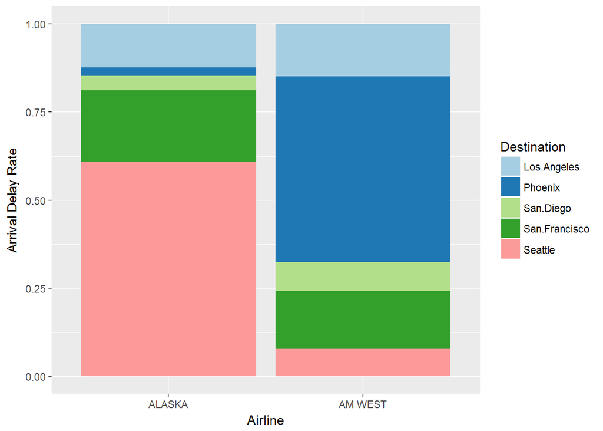

```r
# plot arrival delay rate for the two Airlines accross five destinations with stacked bar graph
ggplot(airdelay_tidy2, aes(x = Airline, y = Delayed_to_all, fill = Destination)) +
  geom_bar(stat="identity", position = "fill") +
  labs(y = "Arrival Delay Rate") +
  scale_fill_brewer(palette = "Paired")
```

**Figure 4. The stacked bar graph for the arrival-delay rates of ALASKA Airline and AM WEST accross the five airports.**

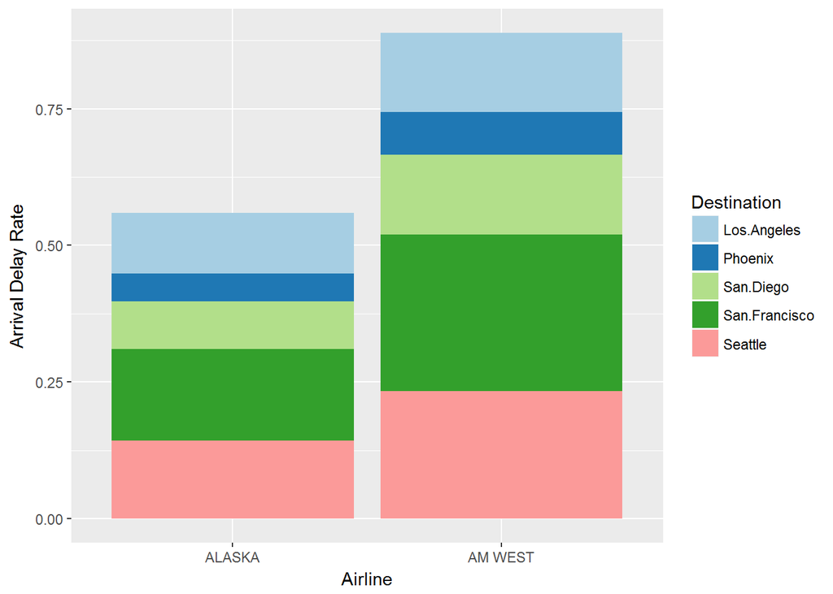

```r
# plot arrival delay rate for the two Airlines accross five destinations with stacked bar graph
ggplot(airdelay_tidy1, aes(x = Airline, y = Proportion_delayed, fill = Destination)) +
  geom_bar(stat="identity") +
  labs(y = "Arrival Delay Rate") +
  scale_fill_brewer(palette = "Paired")
```

**Figure 5. The stacked bar graph for the individual arrival-delay/individual flights to a airport of ALASKA Airline and AM WEST accross the five airports.**

According to Figure 3, the Flights to San Francisco and Seattle accounts for 75% and 10% of the businesses of ALASKA Airline and AM WEST Airline respectively. The arrival-delay rate at these two airports for bother Airlines accounts for around 50% of their total delayed events and being the high for both Airlines, suggesting these two airports are very busy and congested and their schedules need to be optimized.

```r
# make groupies observations and change the units of analysis
airdelay_tidy3 <- airdelay_tidy1 %>%
  group_by(Airline) %>%
  summarise(delayed = sum(delayed), on_time = sum(on_time), Total = sum(Total)) %>%
  gather("Performance","Number",2:4)
kable(airdelay_tidy3)
```

| Airline | Performance | Number |
| --- | --- | --- |
| ALASKA | delayed | 501 |
| AM WEST | delayed | 787 |
| ALASKA | on_time | 3274 |
| AM WEST | on_time | 6438 |
| ALASKA | Total | 3775 |
| AM WEST | Total | 7225 |

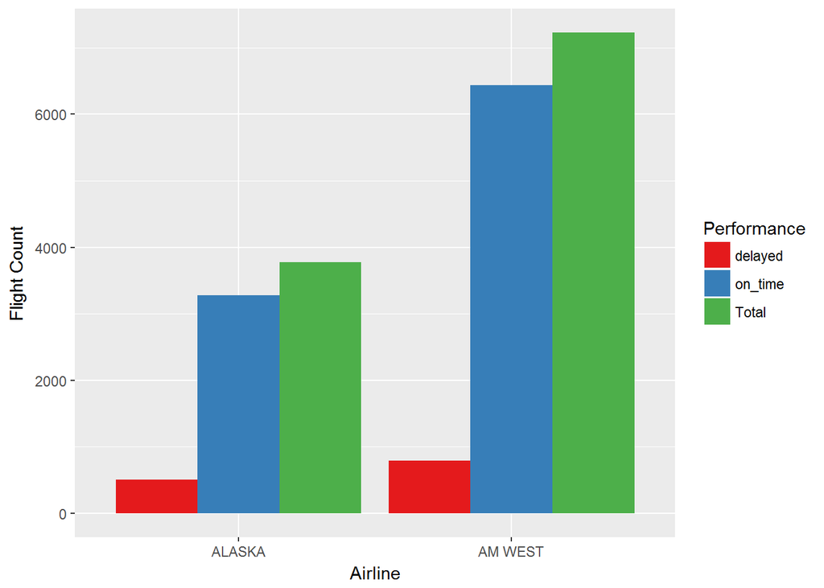

```r
# plot the total counts of flights arrived on time or delayed for the twe Airlines
ggplot(airdelay_tidy3, aes(x = Airline, y = Number, fill = Performance)) +
  geom_bar(stat="identity", position = "dodge") +
  labs(y = "Flight Count") +
  scale_fill_brewer(palette = "Set1")
```

**Figure 6. The total counts of flights arrived on time or delayed of ALASKA Airline and AM WEST.**

AM WEST Airline flies more than ALASKA Airline and AM WEST Airline has higher counts of flights on either arrived on time or delayed.

```r
airdelay_tidy4 <- airdelay_tidy1 %>%
  group_by(Airline) %>%
  gather("Number_category","Number", 3:5)
airdelay_tidy3[,3:4] <- NULL
kable(airdelay_tidy4)
```

| Airline | Destination | Proportion_delayed | Proportion_ontime | Number_category | Number |
| --- | --- | --- | --- | --- | --- |
| ALASKA | Los.Angeles | 0.1109123 | 0.8890877 | delayed | 62 |
| ALASKA | Phoenix | 0.0515021 | 0.9484979 | delayed | 12 |
| ALASKA | San.Diego | 0.0862069 | 0.9137931 | delayed | 20 |
| ALASKA | San.Francisco | 0.1685950 | 0.8314050 | delayed | 102 |
| ALASKA | Seattle | 0.1421249 | 0.8578751 | delayed | 305 |
| AM WEST | Los.Angeles | 0.1442663 | 0.8557337 | delayed | 117 |
| AM WEST | Phoenix | 0.0789724 | 0.9210276 | delayed | 415 |
| AM WEST | San.Diego | 0.1450893 | 0.8549107 | delayed | 65 |
| AM WEST | San.Francisco | 0.2873051 | 0.7126949 | delayed | 129 |
| AM WEST | Seattle | 0.2328244 | 0.7671756 | delayed | 61 |
| ALASKA | Los.Angeles | 0.1109123 | 0.8890877 | on_time | 497 |
| ALASKA | Phoenix | 0.0515021 | 0.9484979 | on_time | 221 |
| ALASKA | San.Diego | 0.0862069 | 0.9137931 | on_time | 212 |
| ALASKA | San.Francisco | 0.1685950 | 0.8314050 | on_time | 503 |
| ALASKA | Seattle | 0.1421249 | 0.8578751 | on_time | 1841 |
| AM WEST | Los.Angeles | 0.1442663 | 0.8557337 | on_time | 694 |
| AM WEST | Phoenix | 0.0789724 | 0.9210276 | on_time | 4840 |
| AM WEST | San.Diego | 0.1450893 | 0.8549107 | on_time | 383 |
| AM WEST | San.Francisco | 0.2873051 | 0.7126949 | on_time | 320 |
| AM WEST | Seattle | 0.2328244 | 0.7671756 | on_time | 201 |
| ALASKA | Los.Angeles | 0.1109123 | 0.8890877 | Total | 559 |
| ALASKA | Phoenix | 0.0515021 | 0.9484979 | Total | 233 |
| ALASKA | San.Diego | 0.0862069 | 0.9137931 | Total | 232 |
| ALASKA | San.Francisco | 0.1685950 | 0.8314050 | Total | 605 |
| ALASKA | Seattle | 0.1421249 | 0.8578751 | Total | 2146 |
| AM WEST | Los.Angeles | 0.1442663 | 0.8557337 | Total | 811 |
| AM WEST | Phoenix | 0.0789724 | 0.9210276 | Total | 5255 |
| AM WEST | San.Diego | 0.1450893 | 0.8549107 | Total | 448 |
| AM WEST | San.Francisco | 0.2873051 | 0.7126949 | Total | 449 |
| AM WEST | Seattle | 0.2328244 | 0.7671756 | Total | 262 |

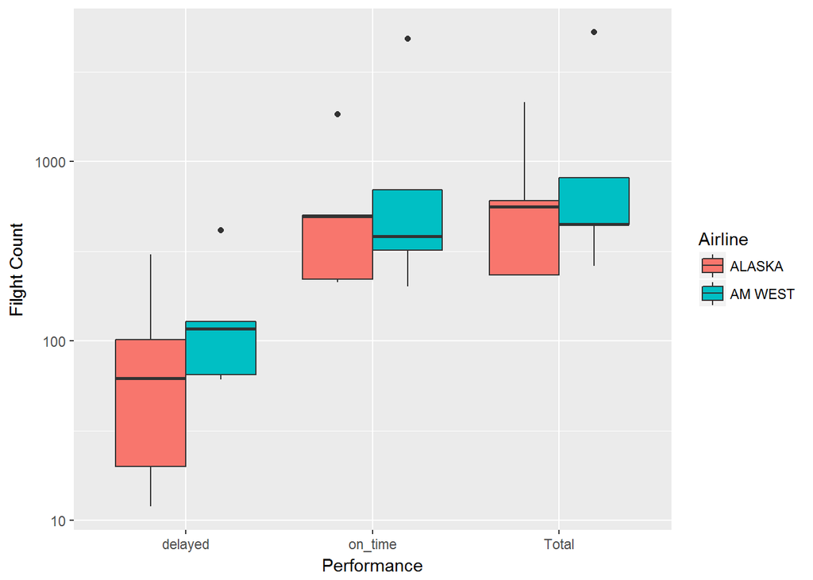

```r
ggplot(airdelay_tidy4, aes(x = factor(Number_category), y = Number, fill = Airline )) +
  geom_boxplot() +
  labs(x = "Performance", y = "Filght Count") +
  theme(axis.text.x = element_text(vjust = 1, hjust = 0.5)) +
  scale_y_log10()
```

**Figure 7. The overall performance of ALASKA Airline and AM WEST Airline.**

The median of delayed arrival of ALASKA Airline is smaller than that of AM WEST Airline. On the countrary, the median of on time arrivle of ALASKA Airline is larger than that of AM WEST Airline. These observations suggest that ALASKA Airline did better in on-time performance.